# QC and UMAP of patch-seq cells

Jeremy Miller

March 26, 2025

# Overview

This code describes how to generate QC calls and UMAP coordinates for the patch-seq cells using Seurat.

This must be run after the first two code documents were run; however, this code block was run on a Windows machine since the docker environment does not work well with Seurat. See sessionInfo() at the end for details. We also assume you have already moved to an appropriate working environment.

## Open the preprocessed and premapped data and set-up the space

Now let’s prepare our environment.

```r
## Load the libraries
suppressPackageStartupMessages({
  library(Seurat)  # We are using Seurat Version 4. More specifically, Seurat_4.4.0 and SeuratObject_5.0.0
})

## Allow for more memory in Seurat (64GB RAM in this case)
options(future.globals.maxSize = 64000 * 1024^2)
set.seed(42)
```

Now load the previously calculated data.

```r
load("patch_and_facs.RData")
```

## Integrate patch-seq and and FACS cells using Seurat FOR QC!

In this section we are going to integrate Patch-seq and dissociated cells using Seurat. First, let’s set up the Seurat object.

```r
## Create data and metadata files
allGenes     <- intersect(rownames(datPatch),rownames(datMTG))
all.data     <- cbind(datMTG[allGenes,],datPatch[allGenes,])
lenD         <- dim(datMTG)[2]
clusterPatch <- mapping.results$cluster_label_Hierarchical
subclassPatch<- mapping.results$subclass_label_Hierarchical
all.metadata <- data.frame( celltype  = c(as.character(annoMTG$cluster_label),clusterPatch),
                            subclass  = c(as.character(annoMTG$subclass_label),subclassPatch),
                            source    = c(rep("AIBS",lenD),c("AIBS","other")[grepl("x",annoPatch$cell_specimen_project)+1]),
                            platform  = c(rep("dissociated",lenD),rep("patch-seq",dim(annoPatch)[1])))
rownames(all.metadata) <- colnames(all.data)

## Create Seurat object
all.seurat <- CreateSeuratObject(counts = all.data, meta.data = all.metadata)
```

Next, perform the data integration.

```r
# Split by condition
patch.list <- SplitObject(object = all.seurat, split.by = "platform")

# Choose all markers derived from the hierarchical mapping algorithm for mapping only to glutamatergic types that have logCPM>1 as integration anchor features
patch_features <- markers_glutamatergic
mean_EXP       <- rowMeans(datMTG)
patch_features <- intersect(patch_features,rownames(datMTG)[mean_EXP>1])

# Find integration anchors
set.seed(10)  # I don't think this is necessary, but just in case...
patch.anchors  <- FindIntegrationAnchors(object.list = patch.list, reference = 1,  # Reference is dissociated cells
                                         verbose=FALSE, anchor.features = patch_features)
```

```
  |                                                  | 0 % ~calculating
  |++++++++++++++++++++++++++++++++++++++++++++++++++| 100% elapsed=39s
```

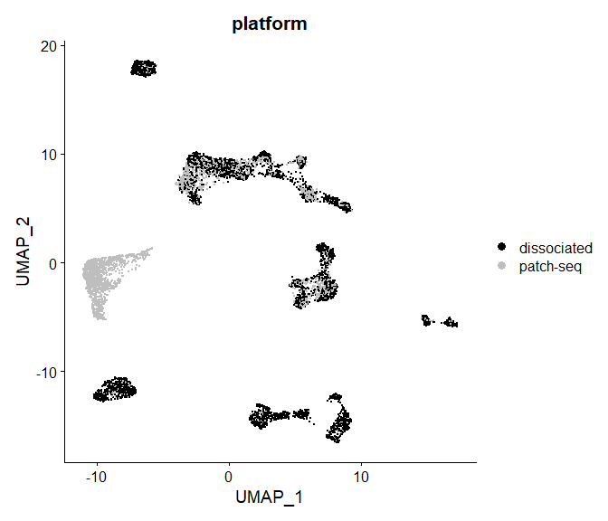

```r
# this command creates an 'integrated' data assay
patch.combined <- IntegrateData(anchorset = patch.anchors, verbose=FALSE)

# Perform the integration analysis
DefaultAssay(patch.combined) <- "integrated"

# Calculate UMAP
pcs <- 30
patch.combined <- ScaleData(patch.combined, verbose = FALSE)
patch.combined <- RunPCA(patch.combined, npcs = pcs, verbose = FALSE)
patch.combined <- RunUMAP(patch.combined, reduction = "pca", dims = 1:pcs, verbose = FALSE)

DimPlot(patch.combined, reduction = "umap", group.by = "platform", label = FALSE, cols=c("black","grey"), shuffle=TRUE)
```

```r
DimPlot(patch.combined[,patch.combined$platform=="dissociated"], reduction = "umap", group.by = "celltype", label = TRUE, label.size = 2.5) + NoLegend()

# Save to pdf also
pdf("umap_combined_QC_ONLY.pdf",height = 6, width=7)
```

```r
DimPlot(patch.combined, reduction = "umap", group.by = "platform", label = FALSE, cols=c("black","grey"), shuffle=TRUE)
DimPlot(patch.combined[,patch.combined$platform=="dissociated"], reduction = "umap", group.by = "celltype", label = TRUE, label.size = 2.5) + NoLegend()
```

[figure not shown]

```r
dev.off()
```

There seem to be good alignment for most cells, but then there is also a big cloud of low-quality cells. **Previous work shows that this cloud of patch-seq only cells is a reasonable way of assigning cells as passing vs. failing QC!**

Next, let’s perform clustering on the UMAP space and determine a sensible QC cutoff.

```r
patch.combined <- FindNeighbors(patch.combined, reduction = "umap", dims=1:2, verbose = FALSE)
patch.combined <- FindClusters(patch.combined, resolution = 0.01, verbose = FALSE)
pdf("remove_bad_cells.pdf",height=8,width=8)
DimPlot(patch.combined, reduction = "umap") #
kp <- !is.element(Idents(patch.combined),c(1))
DimPlot(patch.combined[,kp], reduction = "umap")
```

```r
dev.off()
```

```r
seuratQCpass = setNames(kp,names(Idents(patch.combined)))
seuratQCpass[all.metadata$platform!="dissociated"][mapping.results$class_label_assignment_winner=="Neuronal: GABAergic"] = FALSE  # Manually set anything mapping to a GABAergic type to FALSE (1 cell)
table(seuratQCpass[all.metadata$platform=="patch-seq"])
```

```
FALSE  TRUE
 1320  1491
```

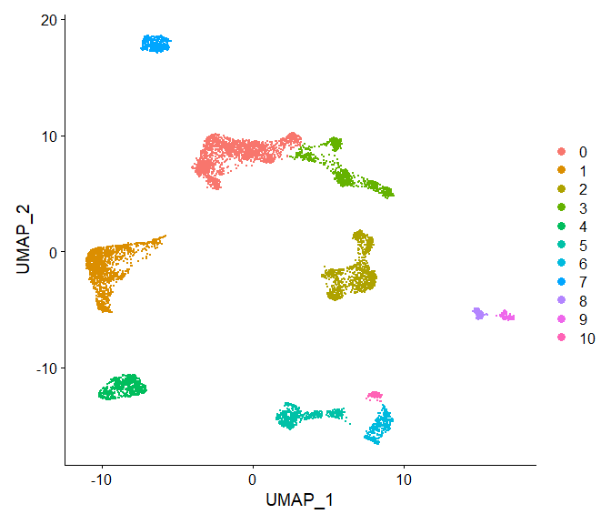

```r
write.csv(data.frame(sample_name=names(seuratQCpass),seuratQCpass=seuratQCpass)[all.metadata$platform=="patch-seq",],"seuratQCpass_SEAAD.csv")

DimPlot(patch.combined, reduction = "umap") #
```

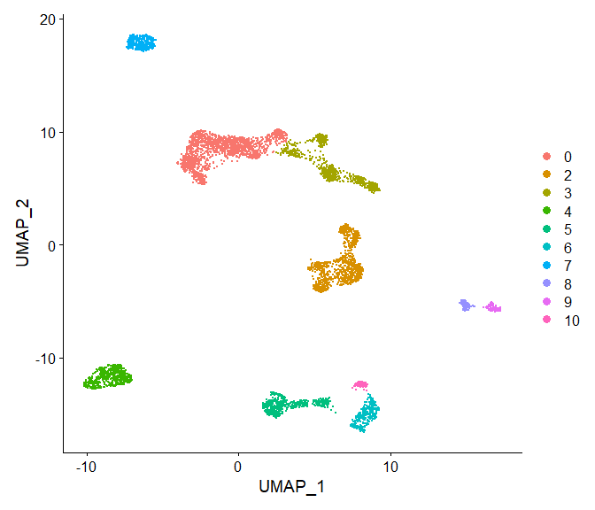

```r
DimPlot(patch.combined[,kp], reduction = "umap")
```

## Integrate patch-seq and and FACS cells using Seurat FOR THE ACTUAL PAPER.

Now run the integration.

```r
# Split by condition
subset.seurat <- CreateSeuratObject(counts = all.data[,seuratQCpass], meta.data = all.metadata[seuratQCpass,])
subset.list   <- SplitObject(object = subset.seurat, split.by = "platform")

set.seed(10)  # I don't think this is necessary, but just in case...
subset.anchors  <- FindIntegrationAnchors(object.list = subset.list, reference = 1,  # Reference is dissociated cells
                                         verbose=FALSE, anchor.features = patch_features)
```

```
  |                                                  | 0 % ~calculating
  |++++++++++++++++++++++++++++++++++++++++++++++++++| 100% elapsed=26s
```

```r
# this command creates an 'integrated' data assay
subset.combined <- IntegrateData(anchorset = subset.anchors, verbose=FALSE)

# Perform the integration analysis
DefaultAssay(subset.combined) <- "integrated"

# Calculate UMAP
pcs <- 30
subset.combined <- ScaleData(subset.combined, verbose = FALSE)
subset.combined <- RunPCA(subset.combined, npcs = pcs, verbose = FALSE)
subset.combined <- RunUMAP(subset.combined, reduction = "pca", dims = 1:pcs, verbose = FALSE)

pdf("integrated_umap_combined.pdf", height=6, width=7)
DimPlot(subset.combined, reduction = "umap", group.by = "platform", label = FALSE, cols=c("black","grey"), shuffle=TRUE)
dev.off()
```

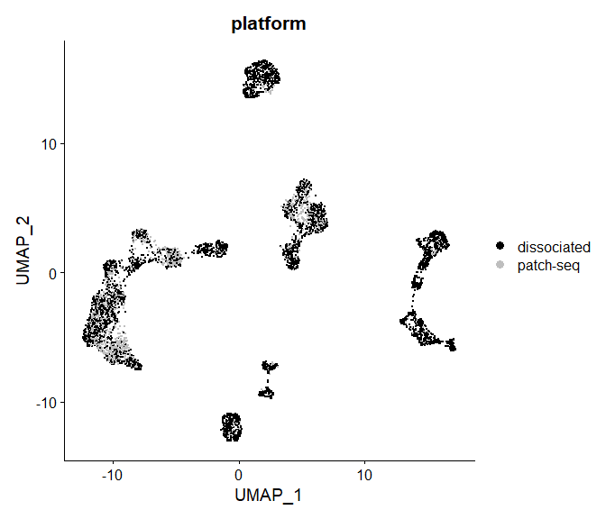

```r
DimPlot(subset.combined, reduction = "umap", group.by = "platform", label = FALSE, cols=c("black","grey"), shuffle=TRUE)
```

Visualize some subclass and cell type plots.

```r
pdf("integrated_umap_combined_plots2.pdf",height=8,width=15)
DimPlot(subset.combined, reduction = "umap", group.by = "celltype", split.by = "platform", label = FALSE) + NoLegend()
DimPlot(subset.combined, reduction = "umap", group.by = "celltype", split.by = "platform", label = TRUE, label.size = 2.5) + NoLegend()
```

```r
DimPlot(subset.combined, reduction = "umap", group.by = "subclass", split.by = "platform", label = FALSE) + NoLegend()
DimPlot(subset.combined, reduction = "umap", group.by = "subclass", split.by = "platform", label = TRUE, label.size = 4.5) + NoLegend()
```

```r
dev.off()
```

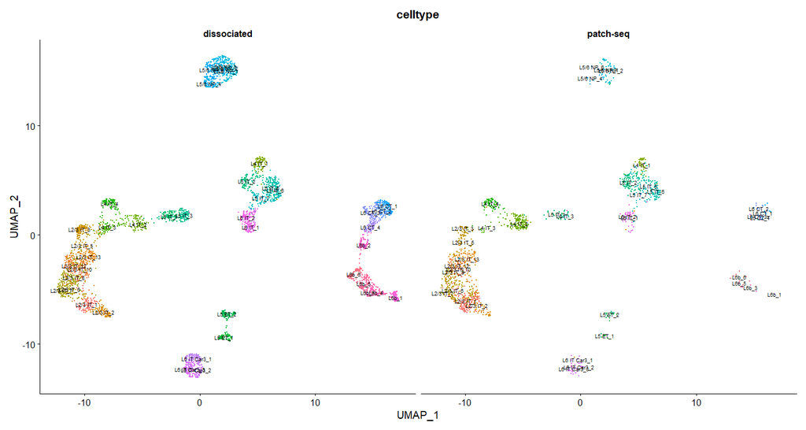

```r
DimPlot(subset.combined, reduction = "umap", group.by = "celltype", split.by = "platform", label = TRUE, label.size = 2.5) + NoLegend()
```

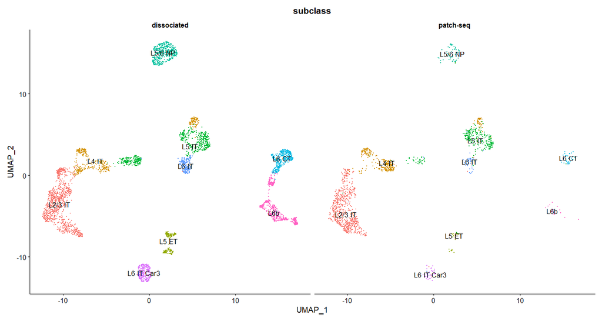

```r
DimPlot(subset.combined, reduction = "umap", group.by = "subclass", split.by = "platform", label = TRUE, label.size = 4.5) + NoLegend()
```

There appear to be some minor differences in cell type assignments, but in looking at the plots by eye, I can’t make any sense out of which ones look “better” or “worse”. Let’s output the results then compare results with morphoelectric characteristics.

## Output results to csv

First write a file with the merged FACS (dissociated) and patch-seq data for UMAP creation.

```r
anno_merge <- data.frame(all.metadata, seuratQCpass, patch.combined@reductions$umap@cell.embeddings)
colnames(anno_merge) <- gsub("UMAP","FOR_QC_ONLY_UMAP",colnames(anno_merge))

subset.umap  <- subset.combined@reductions$umap@cell.embeddings
anno_merge$UMAP_1 <- 0
anno_merge$UMAP_2 <- 0
anno_merge[rownames(subset.umap),c("UMAP_1","UMAP_2")] = subset.umap

write.csv(anno_merge,"FACS_patchseq_QC_and_UMAP.csv")
write.csv(anno_merge[anno_merge$platform!="dissociated",],"patchseq_QC_and_UMAP.csv")
```

[session information not shown]